# House Prices - Advanced Regression Techniques5

In this exercise, we’ll try model stacking separately for numeric and factor variables. We’ll also use preprocessing load the required packages first

```r
library(mlr,quietly = TRUE,warn.conflicts = FALSE)
library(dplyr,quietly = TRUE,warn.conflicts = FALSE)
library(ggplot2,quietly = TRUE,warn.conflicts = FALSE)
library(caret,quietly = TRUE,warn.conflicts = FALSE)
library(purrr,quietly = TRUE,warn.conflicts = FALSE)
library(data.table,quietly = TRUE,warn.conflicts = FALSE)
library(readr,quietly = TRUE,warn.conflicts = FALSE)
library(Boruta,warn.conflicts = FALSE)
library(xgboost,quietly = TRUE,warn.conflicts = FALSE)
```

Load the test and train datasets

```r
train=read.csv("train.csv",stringsAsFactors = FALSE)
test=read.csv("test.csv",stringsAsFactors = FALSE)
```

Rbind the two datasets to perform feature engineering, will later separate the two datasets again. Remove the variable Sale Price from the training set

```r
SalePrice=train$SalePrice
train$SalePrice=NULL
train_test=rbind(train,test)
```

Find the str of the combined train_test dataset. Also take the summary

```r
str(train_test)

summary(train_test)
```

[output not shown]

Take all ‘Character’ class types and convert to factor (categorical) types. Add other numeric variables identified above and convert to factor

```r
trn_tst_chr=train_test %>%
  select_if(is.character) %>%
  mutate_each(funs(as.factor))
str(trn_tst_chr)
```

```
'data.frame':   2919 obs. of  43 variables:
 $ MSZoning     : Factor w/ 5 levels "C (all)","FV",..: 4 4 4 4 4 4 4 4 5 4 ...
 $ Street       : Factor w/ 2 levels "Grvl","Pave": 2 2 2 2 2 2 2 2 2 2 ...
 $ Alley        : Factor w/ 2 levels "Grvl","Pave": NA NA NA NA NA NA NA NA NA NA ...
 $ LotShape     : Factor w/ 4 levels "IR1","IR2","IR3",..: 4 4 1 1 1 1 4 1 4 4 ...
 $ LandContour  : Factor w/ 4 levels "Bnk","HLS","Low",..: 4 4 4 4 4 4 4 4 4 4 ...
 $ Utilities    : Factor w/ 2 levels "AllPub","NoSeWa": 1 1 1 1 1 1 1 1 1 1 ...
 $ LotConfig    : Factor w/ 5 levels "Corner","CulDSac",..: 5 3 5 1 3 5 5 1 5 1 ...
 $ LandSlope    : Factor w/ 3 levels "Gtl","Mod","Sev": 1 1 1 1 1 1 1 1 1 1 ...
 $ Neighborhood : Factor w/ 25 levels "Blmngtn","Blueste",..: 6 25 6 7 14 12 21 17 18 4 ...
 $ Condition1   : Factor w/ 9 levels "Artery","Feedr",..: 3 2 3 3 3 3 3 5 1 1 ...
 $ Condition2   : Factor w/ 8 levels "Artery","Feedr",..: 3 3 3 3 3 3 3 3 3 1 ...
 $ BldgType     : Factor w/ 5 levels "1Fam","2fmCon",..: 1 1 1 1 1 1 1 1 1 2 ...
 $ HouseStyle   : Factor w/ 8 levels "1.5Fin","1.5Unf",..: 6 3 6 6 6 1 3 6 1 2 ...
 $ RoofStyle    : Factor w/ 6 levels "Flat","Gable",..: 2 2 2 2 2 2 2 2 2 2 ...
```

[output cut: 29 more lines]

find the number of NAs in each of the factor variables

```r
colSums(sapply(trn_tst_chr,is.na))
```

```
     MSZoning        Street         Alley      LotShape   LandContour     Utilities     LotConfig     LandSlope
            4             0          2721             0             0             2             0             0
 Neighborhood    Condition1    Condition2      BldgType    HouseStyle     RoofStyle      RoofMatl   Exterior1st
            0             0             0             0             0             0             0             1
  Exterior2nd    MasVnrType     ExterQual     ExterCond    Foundation      BsmtQual      BsmtCond  BsmtExposure
            1            24             0             0             0            81            82            82
 BsmtFinType1  BsmtFinType2       Heating     HeatingQC    CentralAir    Electrical   KitchenQual    Functional
           79            80             0             0             0             1             1             2
  FireplaceQu    GarageType  GarageFinish    GarageQual    GarageCond    PavedDrive        PoolQC         Fence
         1420           157           159           159           159             0          2909          2348
  MiscFeature      SaleType SaleCondition
         2814             1             0
```

Variables Alley, FireplaceQu, PoolQC, Fence, MiscFeature have very high NAs and are removed

```r
trn_tst_chr$Alley=NULL
trn_tst_chr$FireplaceQu=NULL
trn_tst_chr$PoolQC=NULL
trn_tst_chr$Fence=NULL
trn_tst_chr$MiscFeature=NULL
# re-run the command for finding total NAs in the factor variables
colSums(sapply(trn_tst_chr,is.na))
```

```
     MSZoning        Street      LotShape   LandContour     Utilities     LotConfig     LandSlope  Neighborhood
            4             0             0             0             2             0             0             0
   Condition1    Condition2      BldgType    HouseStyle     RoofStyle      RoofMatl   Exterior1st   Exterior2nd
            0             0             0             0             0             0             1             1
   MasVnrType     ExterQual     ExterCond    Foundation      BsmtQual      BsmtCond  BsmtExposure  BsmtFinType1
           24             0             0             0            81            82            82            79
 BsmtFinType2       Heating     HeatingQC    CentralAir    Electrical   KitchenQual    Functional    GarageType
           80             0             0             0             1             1             2           157
 GarageFinish    GarageQual    GarageCond    PavedDrive      SaleType SaleCondition
          159           159           159             0             1             0
```

All variables with Garage that have missing values should be changed to none, likewise all variablesthat have bmst missing values should also be changed to none. Probably these houses don’t have a garage/ basement

```r
#impute the other garage types using the impute function of mlr package
imp_fctr=impute(trn_tst_chr,cols = list(GarageType="none",GarageFinish="none",GarageQual="none",GarageCond="none",
                                      BsmtQual="none",BsmtCond="none",BsmtExposure="none",BsmtFinType1="none",
                                      BsmtFinType2="none"))
imp_fctr$data
```

| MSZoning | Street | LotShape | LandContour | Utilities | LotConfig | LandSlope | Neighborhood | Condition1 | Condition2 | BldgType | HouseStyle | RoofStyle | RoofMatl | Exterior1st | Exterior2nd | MasVnrType | ExterQual | ExterCond | Foundation | BsmtQual | BsmtCond | BsmtExposure | BsmtFinType1 | BsmtFinType2 | Heating | HeatingQC | CentralAir | Electrical | KitchenQual | … |
| --- | --- | --- | --- | --- | --- | --- | --- | --- | --- | --- | --- | --- | --- | --- | --- | --- | --- | --- | --- | --- | --- | --- | --- | --- | --- | --- | --- | --- | --- | --- |
| RL | Pave | Reg | Lvl | AllPub | Inside | Gtl | CollgCr | Norm | Norm | 1Fam | 2Story | Gable | CompShg | VinylSd | VinylSd | BrkFace | Gd | TA | PConc | Gd | TA | No | GLQ | Unf | GasA | Ex | Y | SBrkr | Gd | … |
| RL | Pave | Reg | Lvl | AllPub | FR2 | Gtl | Veenker | Feedr | Norm | 1Fam | 1Story | Gable | CompShg | MetalSd | MetalSd | None | TA | TA | CBlock | Gd | TA | Gd | ALQ | Unf | GasA | Ex | Y | SBrkr | TA | … |
| RL | Pave | IR1 | Lvl | AllPub | Inside | Gtl | CollgCr | Norm | Norm | 1Fam | 2Story | Gable | CompShg | VinylSd | VinylSd | BrkFace | Gd | TA | PConc | Gd | TA | Mn | GLQ | Unf | GasA | Ex | Y | SBrkr | Gd | … |
| RL | Pave | IR1 | Lvl | AllPub | Corner | Gtl | Crawfor | Norm | Norm | 1Fam | 2Story | Gable | CompShg | Wd Sdng | Wd Shng | None | TA | TA | BrkTil | TA | Gd | No | ALQ | Unf | GasA | Gd | Y | SBrkr | Gd | … |
| RL | Pave | IR1 | Lvl | AllPub | FR2 | Gtl | NoRidge | Norm | Norm | 1Fam | 2Story | Gable | CompShg | VinylSd | VinylSd | BrkFace | Gd | TA | PConc | Gd | TA | Av | GLQ | Unf | GasA | Ex | Y | SBrkr | Gd | … |
| RL | Pave | IR1 | Lvl | AllPub | Inside | Gtl | Mitchel | Norm | Norm | 1Fam | 1.5Fin | Gable | CompShg | VinylSd | VinylSd | None | TA | TA | Wood | Gd | TA | No | GLQ | Unf | GasA | Ex | Y | SBrkr | TA | … |
| RL | Pave | Reg | Lvl | AllPub | Inside | Gtl | Somerst | Norm | Norm | 1Fam | 1Story | Gable | CompShg | VinylSd | VinylSd | Stone | Gd | TA | PConc | Ex | TA | Av | GLQ | Unf | GasA | Ex | Y | SBrkr | Gd | … |
| RL | Pave | IR1 | Lvl | AllPub | Corner | Gtl | NWAmes | PosN | Norm | 1Fam | 2Story | Gable | CompShg | HdBoard | HdBoard | Stone | TA | TA | CBlock | Gd | TA | Mn | ALQ | BLQ | GasA | Ex | Y | SBrkr | TA | … |
| RM | Pave | Reg | Lvl | AllPub | Inside | Gtl | OldTown | Artery | Norm | 1Fam | 1.5Fin | Gable | CompShg | BrkFace | Wd Shng | None | TA | TA | BrkTil | TA | TA | No | Unf | Unf | GasA | Gd | Y | FuseF | TA | … |
| RL | Pave | Reg | Lvl | AllPub | Corner | Gtl | BrkSide | Artery | Artery | 2fmCon | 1.5Unf | Gable | CompShg | MetalSd | MetalSd | None | TA | TA | BrkTil | TA | TA | No | GLQ | Unf | GasA | Ex | Y | SBrkr | TA | … |

[output cut: 990 more lines]

```r
colSums(sapply(imp_fctr$data,is.na))
```

```
     MSZoning        Street      LotShape   LandContour     Utilities     LotConfig     LandSlope  Neighborhood
            4             0             0             0             2             0             0             0
   Condition1    Condition2      BldgType    HouseStyle     RoofStyle      RoofMatl   Exterior1st   Exterior2nd
            0             0             0             0             0             0             1             1
   MasVnrType     ExterQual     ExterCond    Foundation      BsmtQual      BsmtCond  BsmtExposure  BsmtFinType1
           24             0             0             0             0             0             0             0
 BsmtFinType2       Heating     HeatingQC    CentralAir    Electrical   KitchenQual    Functional    GarageType
            0             0             0             0             1             1             2             0
 GarageFinish    GarageQual    GarageCond    PavedDrive      SaleType SaleCondition
            0             0             0             0             1             0
```

```r
trn_tst_chr=imp_fctr$data
#for the remaining variables, we impute using impute mode
imp_fctr=impute(trn_tst_chr,classes = list(factor=imputeMode()))
trn_tst_chr=imp_fctr$data
#check once again for any missing values
colSums(sapply(trn_tst_chr,is.na))
```

```
     MSZoning        Street      LotShape   LandContour     Utilities     LotConfig     LandSlope  Neighborhood
            0             0             0             0             0             0             0             0
   Condition1    Condition2      BldgType    HouseStyle     RoofStyle      RoofMatl   Exterior1st   Exterior2nd
            0             0             0             0             0             0             0             0
   MasVnrType     ExterQual     ExterCond    Foundation      BsmtQual      BsmtCond  BsmtExposure  BsmtFinType1
            0             0             0             0             0             0             0             0
 BsmtFinType2       Heating     HeatingQC    CentralAir    Electrical   KitchenQual    Functional    GarageType
            0             0             0             0             0             0             0             0
 GarageFinish    GarageQual    GarageCond    PavedDrive      SaleType SaleCondition
            0             0             0             0             0             0
```

```r
#no missing values now
```

Next, Take all numerics variables separately

```r
trn_tst_num=sapply(train_test,is.numeric)
trn_tst_numeric=train_test[,trn_tst_num]
#convert year variables to age and remove year variables
library(lubridate)
trn_tst_numeric$builtage=as.numeric(year(today())-trn_tst_numeric$YearBuilt)
trn_tst_numeric$YearBuilt=NULL
trn_tst_numeric$remodelledage=as.numeric(year(today())-trn_tst_numeric$YearRemodAdd)
trn_tst_numeric$YearRemodAdd=NULL
trn_tst_numeric$garageage=as.numeric(year(today())-trn_tst_numeric$GarageYrBlt)
trn_tst_numeric$GarageYrBlt=NULL
trn_tst_numeric$soldAge=as.numeric(year(today())-trn_tst_numeric$YrSold)
trn_tst_numeric$YrSold=NULL
```

Find the number of NAs in the numeric variables

```r
colSums(sapply(trn_tst_numeric,is.na))
```

```
           Id    MSSubClass   LotFrontage       LotArea   OverallQual   OverallCond    MasVnrArea    BsmtFinSF1
            0             0           486             0             0             0            23             1
   BsmtFinSF2     BsmtUnfSF   TotalBsmtSF     X1stFlrSF     X2ndFlrSF  LowQualFinSF     GrLivArea  BsmtFullBath
            1             1             1             0             0             0             0             2
 BsmtHalfBath      FullBath      HalfBath  BedroomAbvGr  KitchenAbvGr  TotRmsAbvGrd    Fireplaces    GarageCars
            2             0             0             0             0             0             0             1
   GarageArea    WoodDeckSF   OpenPorchSF EnclosedPorch    X3SsnPorch   ScreenPorch      PoolArea       MiscVal
            1             0             0             0             0             0             0             0
       MoSold      builtage remodelledage     garageage       soldAge
            0             0             0           159             0
```

```r
#first GarageAge
#next we impute Lot Frontage as a regression linear model function of Lot Area
imp_lotfront=impute(trn_tst_numeric, cols = list(LotFrontage=imputeLearner(makeLearner("regr.lm"),features = "LotArea"),MasVnrArea=0,BsmtFinSF1=0,BsmtFinSF2=0,BsmtUnfSF=0, TotalBsmtSF=0, BsmtFullBath=0, BsmtHalfBath=0, GarageCars=0,GarageArea=0,garageage=0))
imp_lotfront$desc
```

```
Imputation description
Target:
Features: 37; Imputed: 11
impute.new.levels: TRUE
recode.factor.levels: TRUE
dummy.type: factor
```

```r
head(imp_lotfront$data,10)
```

|  | Id | MSSubClass | LotFrontage | LotArea | OverallQual | OverallCond | MasVnrArea | BsmtFinSF1 | BsmtFinSF2 | BsmtUnfSF | TotalBsmtSF | X1stFlrSF | X2ndFlrSF | LowQualFinSF | GrLivArea | BsmtFullBath | BsmtHalfBath | FullBath | HalfBath | BedroomAbvGr | KitchenAbvGr | TotRmsAbvGrd | Fireplaces | GarageCars | GarageArea | WoodDeckSF | OpenPorchSF | EnclosedPorch | X3SsnPorch | … |
| --- | --- | --- | --- | --- | --- | --- | --- | --- | --- | --- | --- | --- | --- | --- | --- | --- | --- | --- | --- | --- | --- | --- | --- | --- | --- | --- | --- | --- | --- | --- |
| 1 | 1 | 60 | 65.00000 | 8450 | 7 | 5 | 196 | 706 | 0 | 150 | 856 | 856 | 854 | 0 | 1710 | 1 | 0 | 2 | 1 | 3 | 1 | 8 | 0 | 2 | 548 | 0 | 61 | 0 | 0 | … |
| 2 | 2 | 20 | 80.00000 | 9600 | 6 | 8 | 0 | 978 | 0 | 284 | 1262 | 1262 | 0 | 0 | 1262 | 0 | 1 | 2 | 0 | 3 | 1 | 6 | 1 | 2 | 460 | 298 | 0 | 0 | 0 | … |
| 3 | 3 | 60 | 68.00000 | 11250 | 7 | 5 | 162 | 486 | 0 | 434 | 920 | 920 | 866 | 0 | 1786 | 1 | 0 | 2 | 1 | 3 | 1 | 6 | 1 | 2 | 608 | 0 | 42 | 0 | 0 | … |
| 4 | 4 | 70 | 60.00000 | 9550 | 7 | 5 | 0 | 216 | 0 | 540 | 756 | 961 | 756 | 0 | 1717 | 1 | 0 | 1 | 0 | 3 | 1 | 7 | 1 | 3 | 642 | 0 | 35 | 272 | 0 | … |
| 5 | 5 | 60 | 84.00000 | 14260 | 8 | 5 | 350 | 655 | 0 | 490 | 1145 | 1145 | 1053 | 0 | 2198 | 1 | 0 | 2 | 1 | 4 | 1 | 9 | 1 | 3 | 836 | 192 | 84 | 0 | 0 | … |
| 6 | 6 | 50 | 85.00000 | 14115 | 5 | 5 | 0 | 732 | 0 | 64 | 796 | 796 | 566 | 0 | 1362 | 1 | 0 | 1 | 1 | 1 | 1 | 5 | 0 | 2 | 480 | 40 | 30 | 0 | 320 | … |
| 7 | 7 | 20 | 75.00000 | 10084 | 8 | 5 | 186 | 1369 | 0 | 317 | 1686 | 1694 | 0 | 0 | 1694 | 1 | 0 | 2 | 0 | 3 | 1 | 7 | 1 | 2 | 636 | 255 | 57 | 0 | 0 | … |
| 8 | 8 | 60 | 70.47293 | 10382 | 7 | 6 | 240 | 859 | 32 | 216 | 1107 | 1107 | 983 | 0 | 2090 | 1 | 0 | 2 | 1 | 3 | 1 | 7 | 2 | 2 | 484 | 235 | 204 | 228 | 0 | … |
| 9 | 9 | 50 | 51.00000 | 6120 | 7 | 5 | 0 | 0 | 0 | 952 | 952 | 1022 | 752 | 0 | 1774 | 0 | 0 | 2 | 0 | 2 | 2 | 8 | 2 | 2 | 468 | 90 | 0 | 205 | 0 | … |
| 10 | 10 | 190 | 50.00000 | 7420 | 5 | 6 | 0 | 851 | 0 | 140 | 991 | 1077 | 0 | 0 | 1077 | 1 | 0 | 1 | 0 | 2 | 2 | 5 | 2 | 1 | 205 | 0 | 4 | 0 | 0 | … |

```r
# again find the total NAs in each variable
colSums(sapply(imp_lotfront$data,is.na))
```

```
           Id    MSSubClass   LotFrontage       LotArea   OverallQual   OverallCond    MasVnrArea    BsmtFinSF1
            0             0             0             0             0             0             0             0
   BsmtFinSF2     BsmtUnfSF   TotalBsmtSF     X1stFlrSF     X2ndFlrSF  LowQualFinSF     GrLivArea  BsmtFullBath
            0             0             0             0             0             0             0             0
 BsmtHalfBath      FullBath      HalfBath  BedroomAbvGr  KitchenAbvGr  TotRmsAbvGrd    Fireplaces    GarageCars
            0             0             0             0             0             0             0             0
   GarageArea    WoodDeckSF   OpenPorchSF EnclosedPorch    X3SsnPorch   ScreenPorch      PoolArea       MiscVal
            0             0             0             0             0             0             0             0
       MoSold      builtage remodelledage     garageage       soldAge
            0             0             0             0             0
```

```r
trn_tst_numeric=imp_lotfront$data
colSums(sapply(trn_tst_numeric,is.na))
```

```
           Id    MSSubClass   LotFrontage       LotArea   OverallQual   OverallCond    MasVnrArea    BsmtFinSF1
            0             0             0             0             0             0             0             0
   BsmtFinSF2     BsmtUnfSF   TotalBsmtSF     X1stFlrSF     X2ndFlrSF  LowQualFinSF     GrLivArea  BsmtFullBath
            0             0             0             0             0             0             0             0
 BsmtHalfBath      FullBath      HalfBath  BedroomAbvGr  KitchenAbvGr  TotRmsAbvGrd    Fireplaces    GarageCars
            0             0             0             0             0             0             0             0
   GarageArea    WoodDeckSF   OpenPorchSF EnclosedPorch    X3SsnPorch   ScreenPorch      PoolArea       MiscVal
            0             0             0             0             0             0             0             0
       MoSold      builtage remodelledage     garageage       soldAge
            0             0             0             0             0
```

```r
# no NAs left in the model
```

Check and remove any constant features (min variation) as they don’t help in machine learning, The percentage of variabilitiy is kept at 5% meaning all features with below 5% variability are removed

```r
trn_tst_numeric=removeConstantFeatures(trn_tst_numeric,perc = 0.05)
```

```
Removing 5 columns: LowQualFinSF,KitchenAbvGr,X3SsnPorch,PoolArea,MiscVal
```

5 variables with low variance were removed. LowQualFinSF,KitchenAbvGr,X3SsnPorch,PoolArea,MiscVal Next visualize intra feature correlation. Load package corrplot

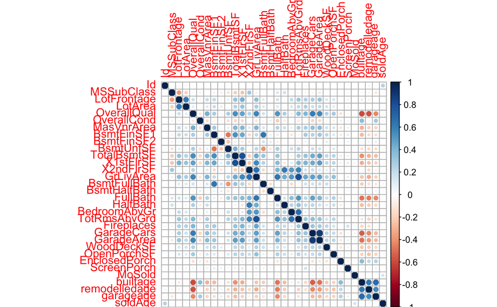

```r
library(corrplot)
numcorr=cor(trn_tst_numeric)
corrplot(numcorr)
```

Find variables of high correlation with each other (multicollinearity) and remove them. Use findCorrelation function from Caret package. All variables with more than 70% correlation are flagged and removed

```r
highcorvar=findCorrelation(numcorr,cutoff = 0.70)
# 3 Variables have high multicollinearity
names(trn_tst_numeric[,highcorvar])
```

```
[1] "GrLivArea"  "X1stFlrSF"  "GarageCars"
```

```r
# "GrLivArea"    "X1stFlrSF"    "GarageCars"  are the variables with high multicollinearity
trn_tst_numeric=trn_tst_numeric[,-highcorvar]
```

Next, we standardize the numerical vaiables using the normalizeFeatures function of mlr package using method= standardize that centers and scales all numerical variables

```r
trn_tst_numeric$Id=NULL
trn_tst_numeric_std=normalizeFeatures(trn_tst_numeric,method = "standardize")
```

combine the two datasets and perform the Boruta function to separate out the feature importance. Before that we separate the data into training and test set

```r
trn_tst_modified=cbind(trn_tst_chr,trn_tst_numeric_std)
trn_mod=trn_tst_modified[1:1460,]
tst_mod=trn_tst_modified[1461:2919,]
boruta_results=Boruta(trn_mod,SalePrice,maxRuns = 100,doTrace = 1,
                        respect.unordered.factors=TRUE,pValue = 0.001)
```

```
After 17 iterations, +1.7 mins:
 confirmed 38 attributes: BedroomAbvGr, BldgType, BsmtFinSF1, BsmtFinType1, BsmtQual and 33 more;
 rejected 7 attributes: Condition2, Heating, LotConfig, MoSold, soldAge and 2 more;
 still have 21 attributes left.

After 21 iterations, +2 mins:
 confirmed 1 attribute: WoodDeckSF;
 still have 20 attributes left.

After 25 iterations, +2.4 mins:
 confirmed 3 attributes: BsmtCond, BsmtFullBath, RoofStyle;
 still have 17 attributes left.

After 28 iterations, +2.6 mins:
 confirmed 1 attribute: BsmtExposure;
 rejected 1 attribute: ExterCond;
 still have 15 attributes left.

After 38 iterations, +3.4 mins:
 rejected 1 attribute: BsmtHalfBath;
 still have 14 attributes left.

After 50 iterations, +4.3 mins:
 confirmed 1 attribute: PavedDrive;
 rejected 1 attribute: RoofMatl;
 still have 12 attributes left.

After 85 iterations, +7.2 mins:
 rejected 1 attribute: Electrical;
 still have 11 attributes left.

After 90 iterations, +7.6 mins:
 rejected 1 attribute: BsmtFinSF2;
 still have 10 attributes left.
```

```r
boruta_results
```

```
Boruta performed 99 iterations in 8.254506 mins.
 44 attributes confirmed important: BedroomAbvGr, BldgType, BsmtCond, BsmtExposure, BsmtFinSF1 and 39
more;
 12 attributes confirmed unimportant: BsmtFinSF2, BsmtHalfBath, Condition2, Electrical, ExterCond and
7 more;
 10 tentative attributes left: BsmtFinType2, Condition1, EnclosedPorch, Functional, LandContour and 5
more;
```

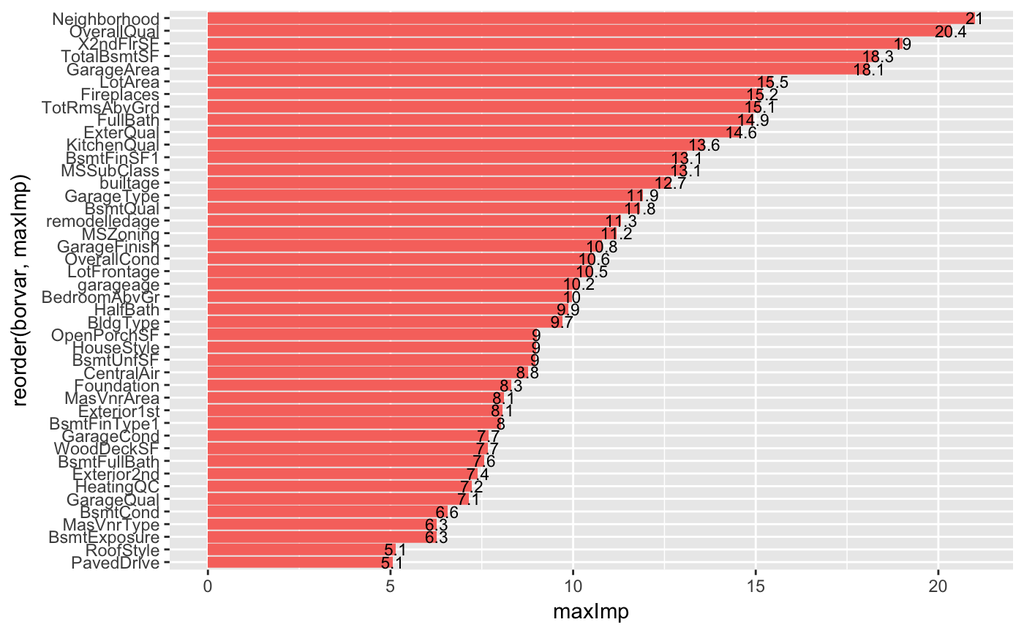

```r
#Boruta performed 249 iterations in 23.68415 mins.
# 47 attributes confirmed important: BedroomAbvGr, BldgType, BsmtCond, BsmtExposure, BsmtFinSF1 and 42
#more;
 #13 attributes confirmed unimportant: BsmtHalfBath, Condition2, Electrical, ExterCond, Functional and
#8 more;
 #6 tentative attributes left: BsmtFinSF2, BsmtFinType2, Condition1, EnclosedPorch, SaleType and 1
#more;
boruta_df=attStats(boruta_results)
boruta_df=boruta_df %>%
  mutate(borvar=row.names(.))
acceptedvar=boruta_df %>%
  filter(decision=="Confirmed"| decision=="Tentative") %>%
  select(borvar)
boruta_df %>%
  filter(decision=="Confirmed") %>%
ggplot(aes(reorder(borvar,maxImp),maxImp,fill=decision))+geom_bar(stat="identity")+coord_flip()+geom_text(aes(borvar,maxImp, label=round(maxImp,1)),size=3)+theme(legend.position = "none")
```

select only features that are confirmed or tentative in both training and test models

```r
trn_mod=trn_mod[,acceptedvar$borvar]
tst_mod=tst_mod[,acceptedvar$borvar]
#remove all other variables
rm(acceptedvar,numcorr,test,train,train_test,trn_tst_numeric_std,trn_tst_modified,trn_tst_chr,trn_tst_num)
rm(trn_tst_numeric)
```

Add the SalePrice variable back to the trn_mod data

```r
trn_mod$SalePrice=log(SalePrice)
```

Now, we convert the categorical variables in both trn_mod and tst_mod datasets to numerical using dummyVars function of caret package

```r
dv=dummyVars("~.",data = trn_mod,fullRank = TRUE)
trn_mod_dum=data.frame(predict(dv,newdata=trn_mod))
names(trn_mod_dum)
```

```
  [1] "MSZoning.FV"           "MSZoning.RH"           "MSZoning.RL"           "MSZoning.RM"
  [5] "LotShape.IR2"          "LotShape.IR3"          "LotShape.Reg"          "LandContour.HLS"
  [9] "LandContour.Low"       "LandContour.Lvl"       "LandSlope.Mod"         "LandSlope.Sev"
 [13] "Neighborhood.Blueste"  "Neighborhood.BrDale"   "Neighborhood.BrkSide"  "Neighborhood.ClearCr"
 [17] "Neighborhood.CollgCr"  "Neighborhood.Crawfor"  "Neighborhood.Edwards"  "Neighborhood.Gilbert"
 [21] "Neighborhood.IDOTRR"   "Neighborhood.MeadowV"  "Neighborhood.Mitchel"  "Neighborhood.NAmes"
 [25] "Neighborhood.NoRidge"  "Neighborhood.NPkVill"  "Neighborhood.NridgHt"  "Neighborhood.NWAmes"
 [29] "Neighborhood.OldTown"  "Neighborhood.Sawyer"   "Neighborhood.SawyerW"  "Neighborhood.Somerst"
 [33] "Neighborhood.StoneBr"  "Neighborhood.SWISU"    "Neighborhood.Timber"   "Neighborhood.Veenker"
 [37] "Condition1.Feedr"      "Condition1.Norm"       "Condition1.PosA"       "Condition1.PosN"
 [41] "Condition1.RRAe"       "Condition1.RRAn"       "Condition1.RRNe"       "Condition1.RRNn"
 [45] "BldgType.2fmCon"       "BldgType.Duplex"       "BldgType.Twnhs"        "BldgType.TwnhsE"
 [49] "HouseStyle.1.5Unf"     "HouseStyle.1Story"     "HouseStyle.2.5Fin"     "HouseStyle.2.5Unf"
 [53] "HouseStyle.2Story"     "HouseStyle.SFoyer"     "HouseStyle.SLvl"       "RoofStyle.Gable"
 [57] "RoofStyle.Gambrel"     "RoofStyle.Hip"         "RoofStyle.Mansard"     "RoofStyle.Shed"
```

[output cut: 35 more lines]

```r
#for the tst_mod now
dv2=dummyVars("~.",data=tst_mod,fullRank=TRUE)
tst_mod_dum=data.frame(predict(dv2,newdata=tst_mod))
sapply(X = trn_mod_dum,class)
```

```
          MSZoning.FV           MSZoning.RH           MSZoning.RL           MSZoning.RM          LotShape.IR2
            "numeric"             "numeric"             "numeric"             "numeric"             "numeric"
         LotShape.IR3          LotShape.Reg       LandContour.HLS       LandContour.Low       LandContour.Lvl
            "numeric"             "numeric"             "numeric"             "numeric"             "numeric"
        LandSlope.Mod         LandSlope.Sev  Neighborhood.Blueste   Neighborhood.BrDale  Neighborhood.BrkSide
            "numeric"             "numeric"             "numeric"             "numeric"             "numeric"
 Neighborhood.ClearCr  Neighborhood.CollgCr  Neighborhood.Crawfor  Neighborhood.Edwards  Neighborhood.Gilbert
            "numeric"             "numeric"             "numeric"             "numeric"             "numeric"
  Neighborhood.IDOTRR  Neighborhood.MeadowV  Neighborhood.Mitchel    Neighborhood.NAmes  Neighborhood.NoRidge
            "numeric"             "numeric"             "numeric"             "numeric"             "numeric"
 Neighborhood.NPkVill  Neighborhood.NridgHt   Neighborhood.NWAmes  Neighborhood.OldTown   Neighborhood.Sawyer
            "numeric"             "numeric"             "numeric"             "numeric"             "numeric"
 Neighborhood.SawyerW  Neighborhood.Somerst  Neighborhood.StoneBr    Neighborhood.SWISU   Neighborhood.Timber
            "numeric"             "numeric"             "numeric"             "numeric"             "numeric"
 Neighborhood.Veenker      Condition1.Feedr       Condition1.Norm       Condition1.PosA       Condition1.PosN
            "numeric"             "numeric"             "numeric"             "numeric"             "numeric"
      Condition1.RRAe       Condition1.RRAn       Condition1.RRNe       Condition1.RRNn       BldgType.2fmCon
            "numeric"             "numeric"             "numeric"             "numeric"             "numeric"
      BldgType.Duplex        BldgType.Twnhs       BldgType.TwnhsE     HouseStyle.1.5Unf     HouseStyle.1Story
            "numeric"             "numeric"             "numeric"             "numeric"             "numeric"
    HouseStyle.2.5Fin     HouseStyle.2.5Unf     HouseStyle.2Story     HouseStyle.SFoyer       HouseStyle.SLvl
            "numeric"             "numeric"             "numeric"             "numeric"             "numeric"
      RoofStyle.Gable     RoofStyle.Gambrel         RoofStyle.Hip     RoofStyle.Mansard        RoofStyle.Shed
            "numeric"             "numeric"             "numeric"             "numeric"             "numeric"
  Exterior1st.AsphShn   Exterior1st.BrkComm   Exterior1st.BrkFace    Exterior1st.CBlock   Exterior1st.CemntBd
            "numeric"             "numeric"             "numeric"             "numeric"             "numeric"
  Exterior1st.HdBoard   Exterior1st.ImStucc   Exterior1st.MetalSd   Exterior1st.Plywood     Exterior1st.Stone
            "numeric"             "numeric"             "numeric"             "numeric"             "numeric"
   Exterior1st.Stucco   Exterior1st.VinylSd   Exterior1st.Wd.Sdng   Exterior1st.WdShing   Exterior2nd.AsphShn
            "numeric"             "numeric"             "numeric"             "numeric"             "numeric"
  Exterior2nd.Brk.Cmn   Exterior2nd.BrkFace    Exterior2nd.CBlock   Exterior2nd.CmentBd   Exterior2nd.HdBoard
            "numeric"             "numeric"             "numeric"             "numeric"             "numeric"
  Exterior2nd.ImStucc   Exterior2nd.MetalSd     Exterior2nd.Other   Exterior2nd.Plywood     Exterior2nd.Stone
            "numeric"             "numeric"             "numeric"             "numeric"             "numeric"
   Exterior2nd.Stucco   Exterior2nd.VinylSd   Exterior2nd.Wd.Sdng   Exterior2nd.Wd.Shng    MasVnrType.BrkFace
            "numeric"             "numeric"             "numeric"             "numeric"             "numeric"
      MasVnrType.None      MasVnrType.Stone          ExterQual.Fa          ExterQual.Gd          ExterQual.TA
            "numeric"             "numeric"             "numeric"             "numeric"             "numeric"
    Foundation.CBlock      Foundation.PConc       Foundation.Slab      Foundation.Stone       Foundation.Wood
            "numeric"             "numeric"             "numeric"             "numeric"             "numeric"
```

[output cut: 25 more lines]

```
            "numeric"             "numeric"             "numeric"             "numeric"             "numeric"
         SaleType.Oth           SaleType.WD SaleCondition.AdjLand  SaleCondition.Alloca  SaleCondition.Family
            "numeric"             "numeric"             "numeric"             "numeric"             "numeric"
 SaleCondition.Normal SaleCondition.Partial            MSSubClass           LotFrontage               LotArea
            "numeric"             "numeric"             "numeric"             "numeric"             "numeric"
          OverallQual           OverallCond            MasVnrArea            BsmtFinSF1             BsmtUnfSF
            "numeric"             "numeric"             "numeric"             "numeric"             "numeric"
          TotalBsmtSF             X2ndFlrSF          BsmtFullBath              FullBath              HalfBath
            "numeric"             "numeric"             "numeric"             "numeric"             "numeric"
         BedroomAbvGr          TotRmsAbvGrd            Fireplaces            GarageArea            WoodDeckSF
            "numeric"             "numeric"             "numeric"             "numeric"             "numeric"
          OpenPorchSF         EnclosedPorch           ScreenPorch              builtage         remodelledage
            "numeric"             "numeric"             "numeric"             "numeric"             "numeric"
            garageage             SalePrice
            "numeric"             "numeric"
```

```r
colnames(trn_mod_dum)
```

[output not shown]

```r
highcorvar
```

[output not shown]

```r
train_ens=as.data.frame(ksvm.pred=exp(train_ens$data$response))
```

[output not shown]

```r
getParamSet("regr.randomForest")
rf.lrn=makeLearner("regr.randomForest",par.vals = list(ntree=1000))
rf.train=mlr::train(learner = rf.lrn,task = gbm.task)
rf.train.predict=predict(object = rf.train,task=gbm.task)
train_ens$pred.rf=exp(rf.train.predict$data$response)
rf.predict=predict(object = rf.train,newdata=tst_mod_dum)
test_ens$pred.rf=exp(rf.predict$data$response)
```

```r
submit1=read_csv("sample_submission.csv")
```

```r
glm.resample=resample(learner = glm.lrn,task = glm.task,resampling = glm.resamp,measures = glm.measures,models = TRUE)
```

```
[Resample] cross-validation iter 1: rmse.test.rmse=3.54e+04,rsq.test.mean=0.833
[Resample] cross-validation iter 2: rmse.test.rmse=1.53e+04,rsq.test.mean=0.949
[Resample] cross-validation iter 3: rmse.test.rmse=1.07e+04,rsq.test.mean=0.978
[Resample] cross-validation iter 4: rmse.test.rmse=1.01e+04,rsq.test.mean=0.98
[Resample] cross-validation iter 5: rmse.test.rmse=1.45e+04,rsq.test.mean=0.96
[Resample] cross-validation iter 6: rmse.test.rmse=5.79e+04,rsq.test.mean=0.658
[Resample] cross-validation iter 7: rmse.test.rmse=2.95e+04,rsq.test.mean=0.867
[Resample] Aggr. Result: rmse.test.rmse=2.96e+04,rsq.test.mean=0.889
```

```r
total.bench$results$trn_mod_dum
```

```
$regr.cubist
Resample Result
Task: trn_mod_dum
Learner: regr.cubist
Aggr perf: rmse.test.rmse=0.157,rsq.test.mean=0.841
Runtime: 6.12296

$regr.randomForest
Resample Result
Task: trn_mod_dum
Learner: regr.randomForest
Aggr perf: rmse.test.rmse=0.144,rsq.test.mean=0.866
Runtime: 40.3324

$regr.ksvm
Resample Result
Task: trn_mod_dum
Learner: regr.ksvm
Aggr perf: rmse.test.rmse=0.135,rsq.test.mean=0.884
Runtime: 2.98074

$regr.glmnet
Resample Result
Task: trn_mod_dum
Learner: regr.glmnet
Aggr perf: rmse.test.rmse=0.157,rsq.test.mean=0.841
Runtime: 0.327882

$regr.earth
Resample Result
Task: trn_mod_dum
Learner: regr.earth
Aggr perf: rmse.test.rmse=0.149,rsq.test.mean=0.856
Runtime: 0.964162

$regr.rpart
Resample Result
Task: trn_mod_dum
Learner: regr.rpart
Aggr perf: rmse.test.rmse=0.224,rsq.test.mean=0.68
```

[output cut: 14 more lines]

```
Runtime: 1.38439

$regr.svm
Resample Result
Task: trn_mod_dum
Learner: regr.svm
Aggr perf: rmse.test.rmse=0.143,rsq.test.mean=0.871
Runtime: 5.40856

$regr.nnet
Resample Result
Task: trn_mod_dum
Learner: regr.nnet
Aggr perf: rmse.test.rmse=0.318,rsq.test.mean=0.315
Runtime: 2.31414
```